# Core Quants Week 12 classwork

YOUR NAME

05/03/2020

This week, I am hiding the code by default since you should focus on the interpretation of results. However, you can see all the code by clicking on the arrows (or alternatively, by looking at the Rmd file).

**Source**

```r
library(tidyverse)
```

**Message**

**Message**

**Message**

**Source**

```r
library(interactions) #If you have not yet installed this package, you need to do so before loading it.
library(car) #You might also need to install this
```

**Message**

**Message**

**Message**

**Message**

# Simpson’s paradox and the importance of interactions

Please test whether penguin’s bill length is related to their bill depth (basically how wide it is).

**Source**

```r
penguins <- read_csv("https://raw.githubusercontent.com/allisonhorst/palmerpenguins/master/inst/extdata/penguins.csv")
```

**Message**

**Source**

```r
#Plot bill depth versus bill length and add a lm() regression line.
#What is the relationship?
ggplot(data = penguins, aes(x = bill_depth_mm, y = bill_length_mm)) +
  geom_point(size = 2) +
  geom_smooth(method = "lm", se = FALSE) +
  ggtitle("There appears to be a negative relationship ...")
```

**Message**

**Warning**

```
## Warning: Removed 2 rows containing non-finite values (stat_smooth).
```

**Warning**

```
## Warning: Removed 2 rows containing missing values (geom_point).
```

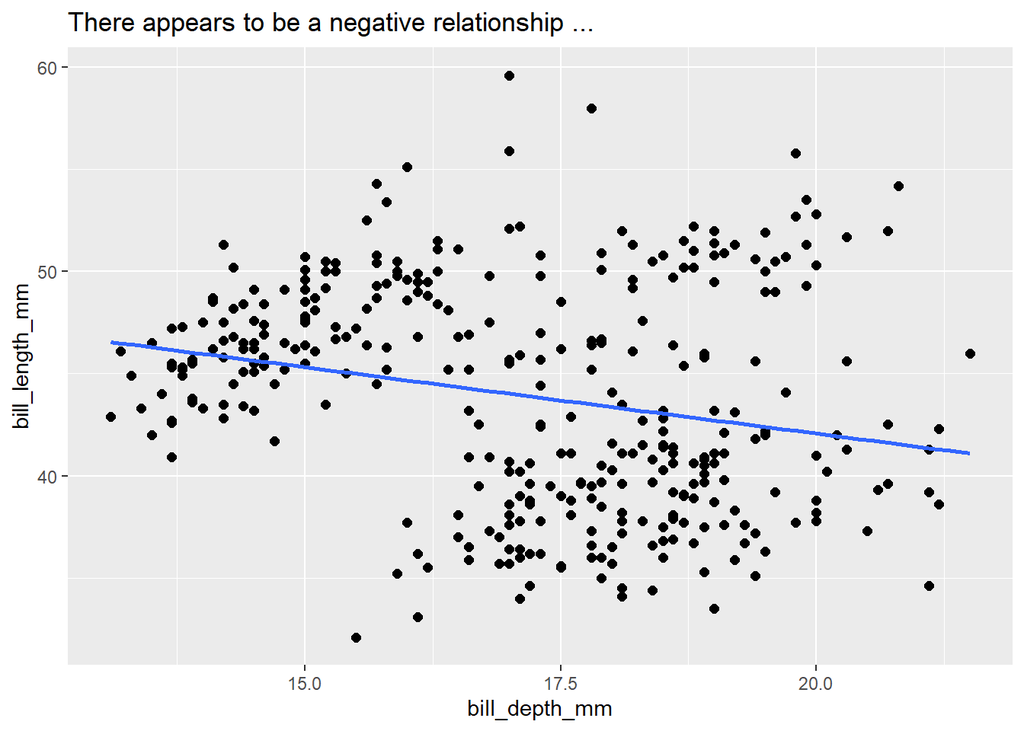

**Source**

```r
#Might this be different by species? Rerun the graph, now
#mapping species onto color. How does the interpretation change?
ggplot(data = penguins, aes(x = bill_depth_mm, y = bill_length_mm, col=species)) +
  geom_point(size = 2) +
  geom_smooth(method = "lm", se = FALSE) +
  ggtitle("... but this masks positive relationships within each species")
```

**Message**

**Warning**

```
## Warning: Removed 2 rows containing non-finite values (stat_smooth).

## Warning: Removed 2 rows containing missing values (geom_point).
```

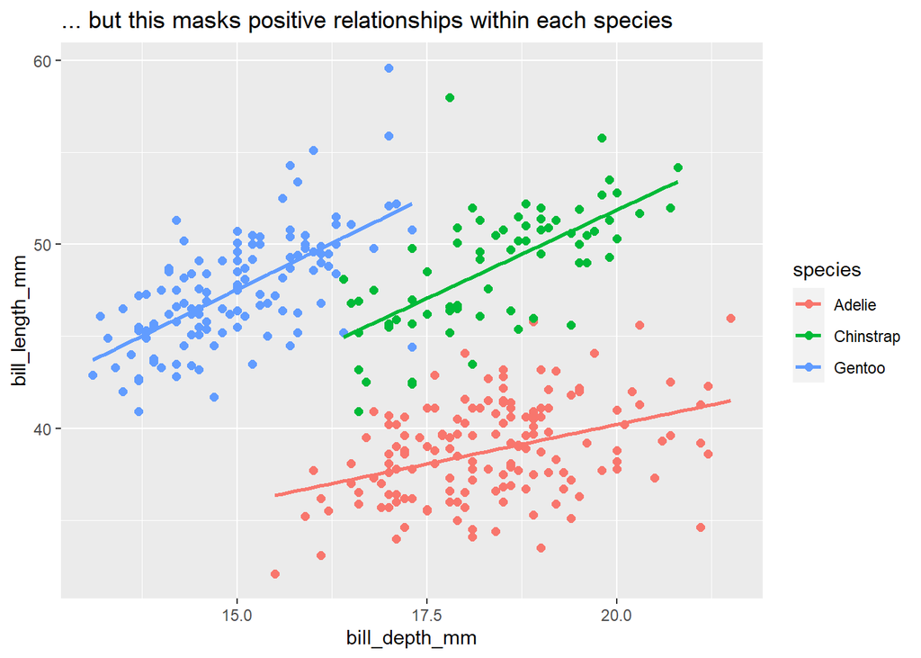

**Source**

```r
#Estimate a linear model that allows you to answer how bill length versus bill depth are related. Do you need a covariate? Do you need an interaction?
lm(bill_length_mm ~ bill_depth_mm * species, penguins) %>% summary()
```

**Output**

```
##
## Call:
## lm(formula = bill_length_mm ~ bill_depth_mm * species, data = penguins)
##
## Residuals:
##     Min      1Q  Median      3Q     Max
## -7.7888 -1.5415  0.0575  1.5873 10.3590
##
## Coefficients:
##                                Estimate Std. Error t value Pr(>|t|)
## (Intercept)                     23.0681     3.0165   7.647 2.18e-13 ***
## bill_depth_mm                    0.8570     0.1641   5.224 3.08e-07 ***
## speciesChinstrap                -9.6402     5.7154  -1.687 0.092590 .
## speciesGentoo                   -5.8386     4.5353  -1.287 0.198850
## bill_depth_mm:speciesChinstrap   1.0651     0.3100   3.435 0.000666 ***
## bill_depth_mm:speciesGentoo      1.1637     0.2789   4.172 3.84e-05 ***
## ---
## Signif. codes:  0 '***' 0.001 '**' 0.01 '*' 0.05 '.' 0.1 ' ' 1
##
## Residual standard error: 2.445 on 336 degrees of freedom
##   (2 observations deleted due to missingness)
## Multiple R-squared:  0.8024, Adjusted R-squared:  0.7995
## F-statistic: 272.9 on 5 and 336 DF,  p-value: < 2.2e-16
```

*If you have a Gentoo penguin, how would you estimate their bill length given their bill depth? What about an Adelie penguin? Write out the two regression formulas and calculate the predicted bill length given a bill depth of 16mm*

Gentoo: pred. bill length = 23.1 - 5.8 + (0.85+1.16) * bill depth –> 16 mm would lead to a prediction of 49.5mm

Adelie: pred. bill length = 23.1 + 0.85 * bill depth –> 16 mm would lead to a prediction of 36.7mm

# Is the climate becoming less stable?

A while ago, we looked at weather data from Heathrow to consider whether April temperatures are a good guide to temperatures in the summer. For that, we ran two regression models - have a look at their output and interpret what you see.

**Source**

```r
weather <- read_csv("https://github.com/LukasWallrich/GoldCoreQuants-materials/raw/main/R%20exercises/data/heathrowdata-metoffice.csv")
```

**Message**

**Source**

```r
weather <- weather %>%
  filter(mm %in% c(4, 8)) %>%
  mutate(temperature_avg = (tmin + tmax) / 2) %>%
  select(yyyy, mm, temperature_avg) %>%
  pivot_wider(names_from = mm, values_from = temperature_avg) %>%
  rename(April = `4`, August = `8`, year = yyyy)

lm(August ~ April, weather) %>% summary()
```

**Output**

```
##
## Call:
## lm(formula = August ~ April, data = weather)
##
## Residuals:
##     Min      1Q  Median      3Q     Max
## -2.2931 -1.0321 -0.1585  0.9480  3.1567
##
## Coefficients:
##             Estimate Std. Error t value Pr(>|t|)
## (Intercept)  14.9455     1.1721  12.751   <2e-16 ***
## April         0.3031     0.1210   2.506   0.0145 *
## ---
## Signif. codes:  0 '***' 0.001 '**' 0.01 '*' 0.05 '.' 0.1 ' ' 1
##
## Residual standard error: 1.35 on 70 degrees of freedom
##   (1 observation deleted due to missingness)
## Multiple R-squared:  0.08232,    Adjusted R-squared:  0.06921
## F-statistic: 6.279 on 1 and 70 DF,  p-value: 0.01454
```

**Source**

```r
lm(August ~ April + year, weather) %>% summary()
```

**Output**

```
##
## Call:
## lm(formula = August ~ April + year, data = weather)
##
## Residuals:
##      Min       1Q   Median       3Q      Max
## -2.00488 -0.90674 -0.05978  0.60530  3.01608
##
## Coefficients:
##               Estimate Std. Error t value Pr(>|t|)
## (Intercept) -45.194300  15.084954  -2.996 0.003798 **
## April         0.070291   0.124283   0.566 0.573517
## year          0.031447   0.007868   3.997 0.000159 ***
## ---
## Signif. codes:  0 '***' 0.001 '**' 0.01 '*' 0.05 '.' 0.1 ' ' 1
##
## Residual standard error: 1.226 on 69 degrees of freedom
##   (1 observation deleted due to missingness)
## Multiple R-squared:  0.2548, Adjusted R-squared:  0.2332
## F-statistic:  11.8 on 2 and 69 DF,  p-value: 3.916e-05
```

**Source**

```r
#Now include an interaction between April and year and interpret the result
#Did the association between April and August change over time? How?
model_int <- lm(August ~ April * year, weather)
summary(model_int)
```

**Output**

```
##
## Call:
## lm(formula = August ~ April * year, data = weather)
##
## Residuals:
##     Min      1Q  Median      3Q     Max
## -2.1064 -0.8990 -0.1874  0.6606  2.8747
##
## Coefficients:
##               Estimate Std. Error t value Pr(>|t|)
## (Intercept) -3.406e+02  1.026e+02  -3.319 0.001453 **
## April        3.015e+01  1.035e+01   2.914 0.004826 **
## year         1.801e-01  5.167e-02   3.485 0.000865 ***
## April:year  -1.513e-02  5.203e-03  -2.907 0.004917 **
## ---
## Signif. codes:  0 '***' 0.001 '**' 0.01 '*' 0.05 '.' 0.1 ' ' 1
##
## Residual standard error: 1.164 on 68 degrees of freedom
##   (1 observation deleted due to missingness)
## Multiple R-squared:  0.3372, Adjusted R-squared:  0.308
## F-statistic: 11.53 on 3 and 68 DF,  p-value: 3.352e-06
```

**Source**

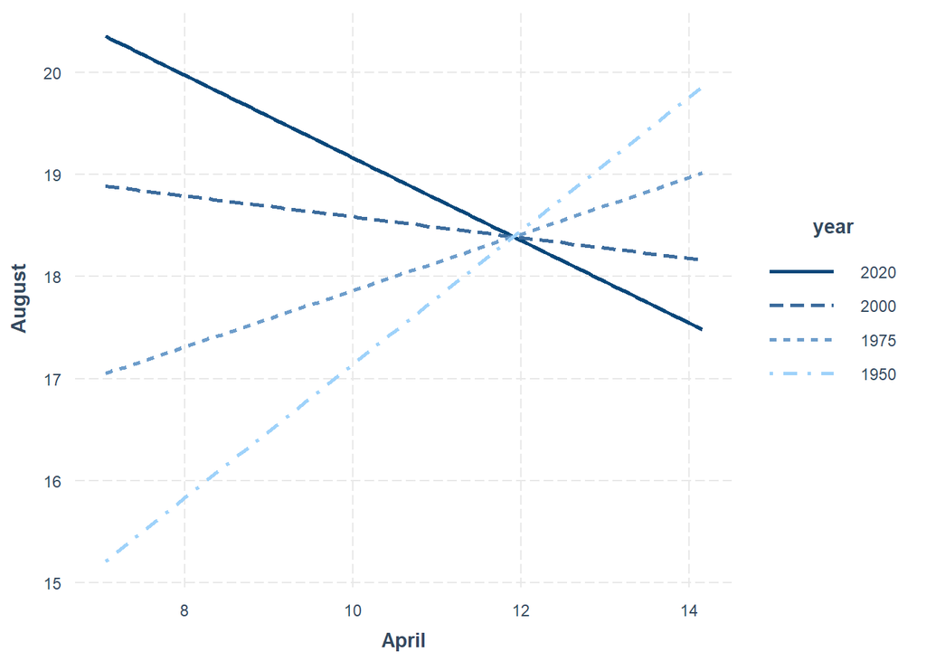

```r
#What does the 'Estimate' for April refer to now? How could you recode the data to turn it into a more meaningful number?

#A simple slopes interaction plot might help to visualise the relationship - but given that the moderator takes very specific and meaningful values, it makes little sense to use the normal lines based on standard deviations of the moderator. Instead, specify a couple of meaningful values of the moderator (year).
interactions::interact_plot(model_int, "April", "year", modx.values = c(1950, 1975, 2000, 2020))
```

**Source**

```r
#When did April temperatures stop being a significant predictor of August temperatures? (You need the johnson_neyman() interval to answer this.) What relationship does it suggest from 2020 on? Should we believe that?
johnson_neyman(model_int, "April", "year")
```

**Output**

```
## JOHNSON-NEYMAN INTERVAL
##
## When year is OUTSIDE the interval [1975.15, 2019.65], the slope of April is
## p < .05.
##
## Note: The range of observed values of year is [1948.00, 2019.00]
```

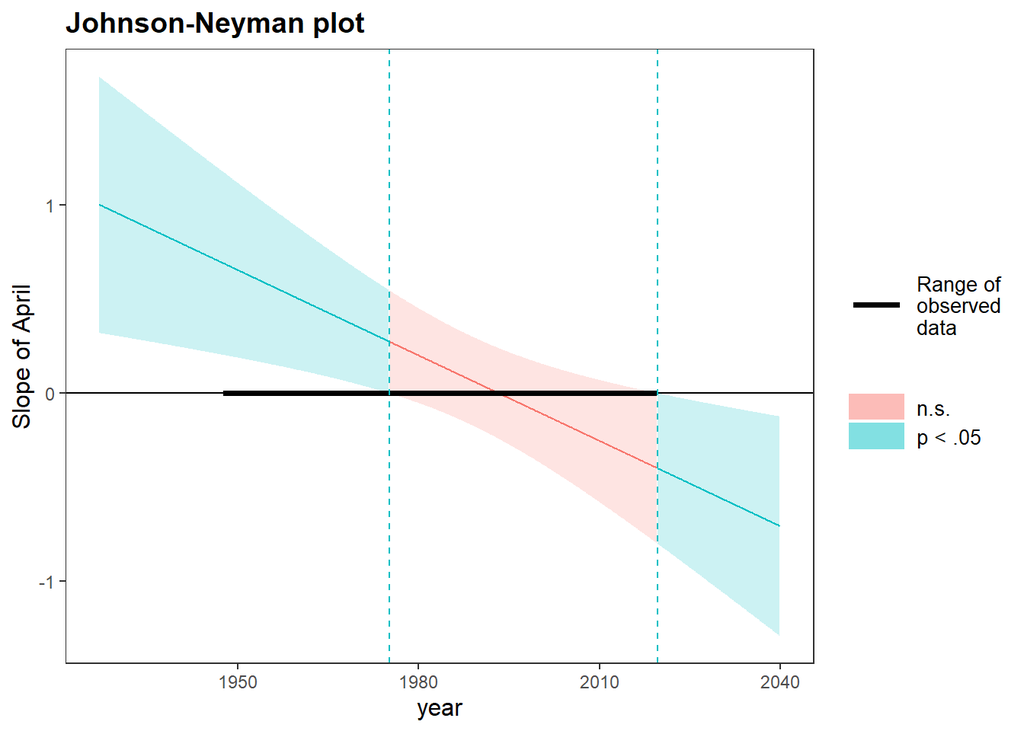

We tested whether April temperatures in a given year would predict August temperatures in the same year. Considering temperatures measured at Heathrow from 1948 to 2019, we found that there was a significant (linear) interaction between April temperatures and the year in predicting August temperatures, B = -0.015, *p* = .005. Johnson-Neyman prediction intervals showed that while April temperatures were a significant positive predictor of August temperatures until 1975, the relationship has not been significant since.